# A jrich worked example

D.R. Miranda Esquivel

29/02/2016

These functions calculate the taxonomic measures presented in Miranda-Esquivel (2016). The package introduces Jack-knife resampling in evolutionary distinctiveness prioritization analysis, as a way to evaluate the support of the ranking in area prioritization, and the persistence of a given area in a conservation analysis.

For further information, you could read http://link.springer.com/chapter/10.1007/978-3-319-22461-9_11

### **1.** An example with a single topology and distribution to reproduce Figure 1 in Miranda-Esquivel (2016)

First of all, we remove everything from the R environment.

```r
#
rm(list=ls())
```

And close the graphic devices, if there is any.

```r
#
if (dev.cur()!=1){dev.off()}
```

Now, we get the latest version of the library, from GitHub.

```r
#library("devtools")

#install_github("Dmirandae/jrich")
```

We load the library before proceeding.

```r
library(jrich)
```

ans set working directory to the R Data (make sure you have changed it to your own directory).

```r
# setwd("./myData/")
```

Now, we can read a tree from `figure1.tre`, which is written in Newick format or we can use directly the tree from the data file.

To read a file form a file use:

```r
tree.figure1 <- read.tree ("yourTree.tre")
```

Or, upload the data set, using the `data` funtion.

```r
 data(tree)
```

We can plot the tree.

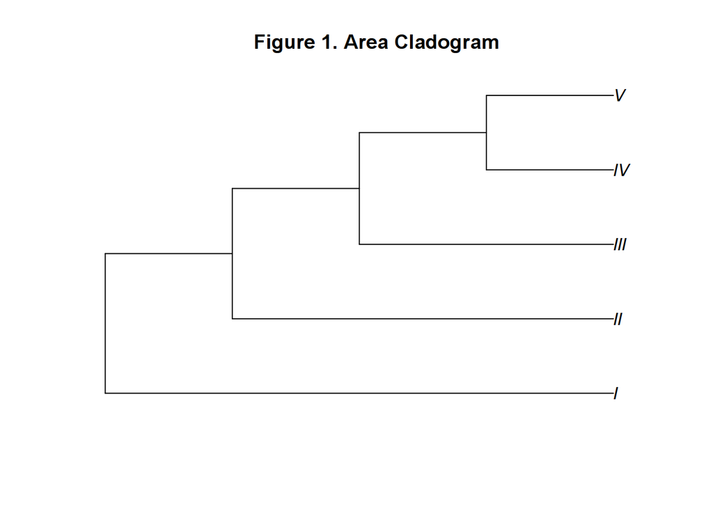

```r
plot(tree, main= "Figure 1. Area Cladogram")
```

We can also read distributions using the species per area format. The distributions could be a csv file with several features: Each line has a species name and an area, and multiple areas for the same species means a widespread taxon in multiple lines.

The following function creates a data frame for the species distributions.

```r
distrib.figure1 <- Read.Data("figure1.csv")

head(distrib.figure1)
```

Also, we could read the example distribution.

```r
data(distribution)
```

We run the initial Index calculation, with a verbose output.

```r
library(jrich)

initial.Values <- Calculate.Index(tree=tree, distrib = distribution, verbose=T)
```

```
## [1] "Deleted  0  out of  5"
```

```r
initial.Values
```

```
##   area I Ie    Is   Ise     W    We    Ws   Wse rich endem jtopol jtip
## 1    A 8  8 0.200 0.364 4.000 4.000 0.158 0.300    1     1      0    0
## 2    B 4  4 0.100 0.182 2.000 2.000 0.079 0.150    1     0      0    0
## 3    C 2  2 0.050 0.091 1.333 1.333 0.053 0.100    1     0      0    0
## 4    D 1  1 0.025 0.045 1.000 1.000 0.039 0.075    1     0      0    0
## 5    E 1  1 0.025 0.045 1.000 1.000 0.039 0.075    1     0      0    0
## 6    F 8  2 0.200 0.091 5.333 1.333 0.211 0.100    4     0      0    0
## 7    G 8  2 0.200 0.091 5.333 1.333 0.211 0.100    4     0      0    0
## 8    H 8  2 0.200 0.091 5.333 1.333 0.211 0.100    4     0      0    0
```

Note that the figures for **Is/Ws** indices here are different from Figure 1 in Miranda-Esquivel 2016, as here are re-scaled to sum 1, but the proportions are exactly the same.

To obtain the same figures for **Is/Ws** indices as in Figure 1, we must use this code:

```r
figure1.Values <-  Calculate.Index(tree=tree, distrib = distribution, verbose=F, standard = "tree")

figure1.Values
```

```
##   area I Ie    Is   Ise     W    We    Ws   Wse rich endem jtopol jtip
## 1    A 8  8 0.500 0.500 4.000 4.000 0.429 0.429    1     1      0    0
## 2    B 4  4 0.250 0.250 2.000 2.000 0.214 0.214    1     0      0    0
## 3    C 2  2 0.125 0.125 1.333 1.333 0.143 0.143    1     0      0    0
## 4    D 1  1 0.062 0.062 1.000 1.000 0.107 0.107    1     0      0    0
## 5    E 1  1 0.062 0.062 1.000 1.000 0.107 0.107    1     0      0    0
## 6    F 8  2 0.500 0.125 5.333 1.333 0.571 0.143    4     0      0    0
## 7    G 8  2 0.500 0.125 5.333 1.333 0.571 0.143    4     0      0    0
## 8    H 8  2 0.500 0.125 5.333 1.333 0.571 0.143    4     0      0    0
```

```r
all.equal(initial.Values,figure1.Values)
```

```
## [1] "Component \"Is\": Mean relative difference: 1.499"
## [2] "Component \"Ise\": Mean relative difference: 0.374"
## [3] "Component \"Ws\": Mean relative difference: 1.71029"
## [4] "Component \"Wse\": Mean relative difference: 0.429"
```

**1.** Correlations between values

Plot the initial Values for the index that “explains” the most with this line:

```r
correlations <- cor(initial.Values[,2:10],initial.Values[,2:10])
```

Do not forget using the following code to avoid the “autocorrelation”.

```r
diag(correlations) <- 0.0
```

Now we can determine the ‘Best’ descriptor:

```r
best.Index <- which.max(apply(correlations,2,sum))

best.Index
```

```
## I
## 1
```

With the following instruction we can get the name of index that displays the highest value, and the row of the column **rich** in which the object is found.

Keep in mind that richness in not a good predictor for all indices.

```r
which(abs(correlations[,"rich"])==max(abs(correlations[,"rich"])))
```

```
## Ws
##  7
```

To plot aesthetic graphics, load the library `ggplot2`.

```r
library(ggplot2)
```

**2.** The index that “explains the most”, without resampling is:

```r
best.Index <-   which.max(apply(correlations,2,sum))

best.Index
```

```
## I
## 1
```

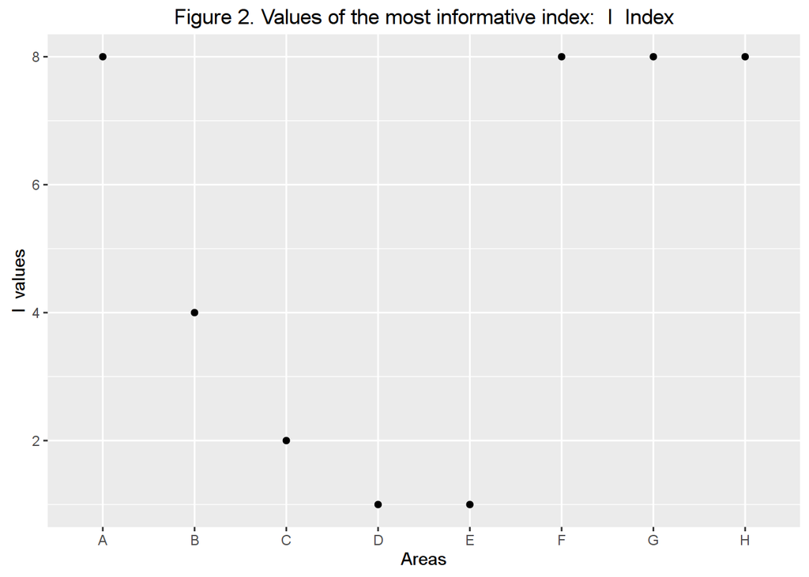

```r
qplot(initial.Values$area,initial.Values[,names(best.Index)], xlab = "Areas",
      ylab =paste(names(best.Index)," values"), main = paste("Figure 2. Values of the most informative index: ",names(best.Index)," Index"))
```

In this example, Areas **A / F / G / H** have the same ranking, as area **A** harbors species **I**, while areas **F / G / H** have the highest absolute richness.

We run the analysis with a single Jackknife replicate with a jtip value of 0.5.

```r
jack.Values <-  Calculate.Index(tree=tree, distrib = distribution,jtip = 0.5)
```

```
## [1] "Deleted  3  out of  5"
```

The absolute difference between these two outputs can be computed with this instruction:

```r
all.equal(initial.Values, jack.Values)
```

```
##  [1] "Component \"I\": Mean relative difference: 0.7567568"
##  [2] "Component \"Ie\": Mean relative difference: 0.7631579"
##  [3] "Component \"Is\": Mean relative difference: 0.65"
##  [4] "Component \"Ise\": Mean relative difference: 1"
##  [5] "Component \"W\": Mean relative difference: 0.6956824"
##  [6] "Component \"We\": Mean relative difference: 0.6816983"
##  [7] "Component \"Ws\": Mean relative difference: 0.5504496"
##  [8] "Component \"Wse\": Mean relative difference: 1"
##  [9] "Component \"rich\": Mean relative difference: 0.6"
## [10] "Component \"endem\": Mean relative difference: 1"
## [11] "Component \"jtip\": Mean absolute difference: 0.5"
```

**3.** But a single replicate is not interesting, therefore we can repeat the process 100 times, using two approaches:

- **3.1** Jackknifing with a jtip value of 0.5, 100 replicates, using the `Calculate.Index` function.

```r
jack.Ranking.100 <- list()
for (i in 1:100){
  ## if you want to get the output number replicate, uncomment this line:
  ##print(paste("replicate #",i), )

  jack.Ranking.100[[i]] <-  as.data.frame(Rank.Indices(Calculate.Index(tree=tree, distrib = distribution, verbose=FALSE,jtip = 0.5)))
}
```

- **3.2** Comparing the whole ranking for the best index, 100 times.

```r
initial.Ranking <-  as.data.frame(Rank.Indices(initial.Values))

jack.Ranking.100.comparison <- NULL

for (i in 1:100){

  if(!all(jack.Ranking.100[[i]][,best.Index] == "X0X")){
    jack.Ranking.100.comparison[i] <- all.equal(initial.Ranking[,best.Index],
                                                  jack.Ranking.100[[i]][,best.Index])
  }else jack.Ranking.100.comparison[i] <- 0
}
```

Get the number of hits or the extent of the Jackknife replicate to recover the initial ranking:

```r
length(which(jack.Ranking.100.comparison==TRUE))
```

```
## [1] 10
```

To estimate the error, we use this code:

```r
length(which(as.data.frame(jack.Ranking.100.comparison)!=TRUE))
```

```
## [1] 90
```

```r
jack.Mismatch <- jack.Ranking.100.comparison[jack.Ranking.100.comparison!=TRUE]

count.Jack.Mismatch <- gsub(" string mismatches","",jack.Mismatch)

count.Jack.Mismatch <- as.numeric(count.Jack.Mismatch)
```

Plot the distribution of the error, not so bell-shaped.

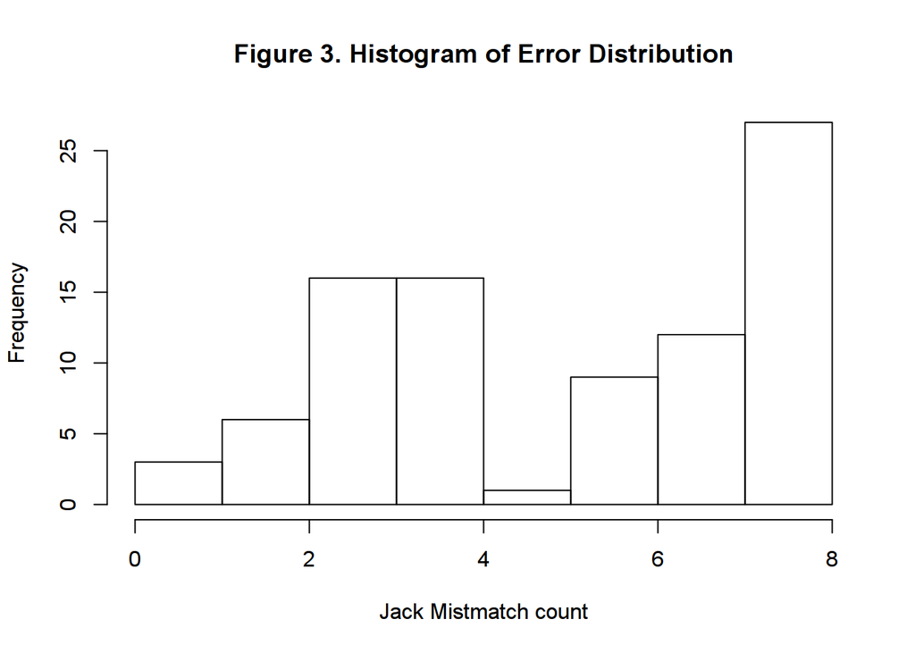

```r
hist(sort(count.Jack.Mismatch,na.last = NA), main = "Figure 3. Histogram of Error Distribution", xlab= "Jack Mistmatch count")
```

Note that `Calculate.Index` recovers the index values while `Best.Index` recovers the ranking comparison.

```r
jack.figure1.jtip05.100replicates <- Best.Index(tree=tree, distrib = distribution, jtip = 0.5, replicates = 50, success = c(1:2))
```

```
## [1] "Deleted  0  out of  5"
## [1] "Deleted  1  out of  5"
## [1] "Deleted  5  out of  5"
## [1] "Deleted  2  out of  5"
## [1] "Deleted  1  out of  5"
## [1] "Deleted  3  out of  5"
## [1] "Deleted  3  out of  5"
## [1] "Deleted  2  out of  5"
## [1] "Deleted  2  out of  5"
## [1] "Deleted  2  out of  5"
## [1] "Deleted  3  out of  5"
## [1] "Deleted  3  out of  5"
## [1] "Deleted  4  out of  5"
## [1] "Deleted  3  out of  5"
## [1] "Deleted  2  out of  5"
```

[output cut: 36 more lines]

```r
jack.figure1.jtip05.100replicates
```

```
##   Wse Ws We  W Ise Is Ie  I
## 1   4 48 22 30   4 30 22 30
```

```r
best.Index = names(jack.figure1.jtip05.100replicates)[c(which(jack.figure1.jtip05.100replicates == max(jack.figure1.jtip05.100replicates)))]
```

[output not shown]

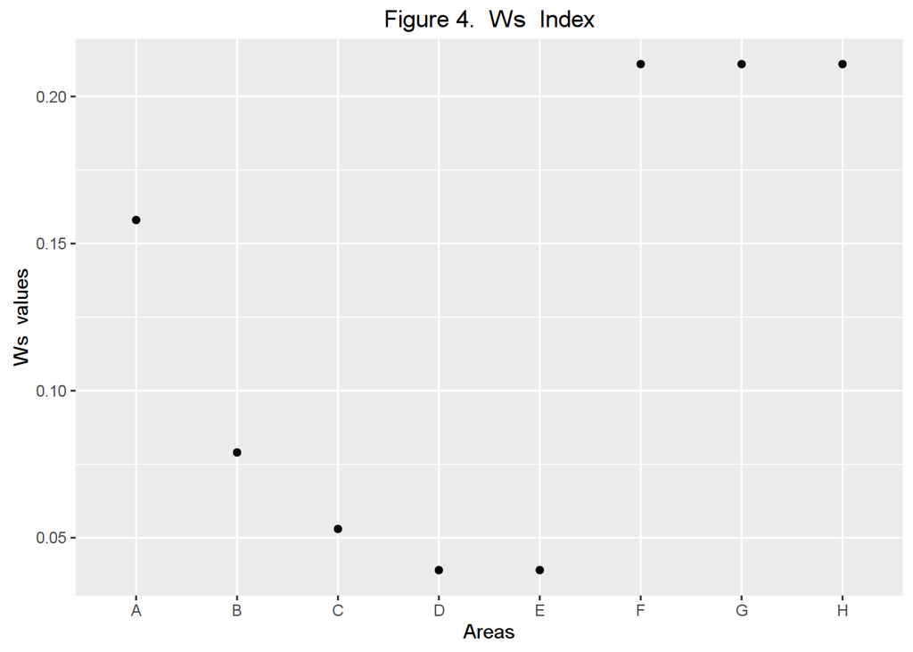

```r
for (i in 1:length(best.Index)){

print(best.Index[i])

print(qplot(initial.Values$area,initial.Values[,best.Index[i]], xlab = "Areas",
      ylab =paste(best.Index[i]," values"), main = paste("Figure 4. ",best.Index[i]," Index")))
}
```

### **2.** An example with two topologies and distributions

For this example, We will work with a tree and a distribution for an real taxon: *Puranius* (These two files could be found in in the data directory).

```r
tree.Puranius <- read.tree ("puranius.tre")

distrib.Puranius <- Read.Data ("puranius.csv.gz")
```

Now we will assign a list to the object `data.Puranius` in order to join the tree and the distribution, which could certainly be made with a function as well. However, I prefer this approach.

```r
data.Puranius  <- list()

data.Puranius[[1]] <- tree.Puranius

data.Puranius[[2]] <- distrib.Puranius

head(data.Puranius)
```

We will proceed just as we did for the first Taxon, thence we got a tree and a distribution for another Taxon: *Janus*.

```r
tree.Janus <- read.tree ("Janus.tre")

distrib.Janus <- Read.Data("Janus.csv.gz")

data.Janus  <- list()

data.Janus[[1]] <- tree.Janus

data.Janus[[2]] <- distrib.Janus

data.Janus
```

The following code creates a list to handle multiple datasets. In this case, the list `Multitaxon1` contains two objects.

```r
Multitaxon1 <- list()

Multitaxon1[[1]] <- data.Janus

Multitaxon1[[2]] <- data.Puranius
```

The function `Multi.Index.Calc` calculates indices values for a MultiData list. For this case, it computes the Initial ranking for `Multitaxon1` with default values. This action is performed just once.

```r
data(Multitaxon1)

initial.Values.Multi <-  Multi.Index.Calc(Multitaxon1)
```

```
## [1] "Deleted  0  out of  20"
## [1] "Deleted  0  out of  20"
```

Before plotting the initial Values for the Index that explains the most, make sure that the library `ggplot2` is loaded.

```r
library(ggplot2)
```

**1.** Correlations between values

Plotting as example, the index value that explains the most is:

```r
correlations.Multi <-  cor(initial.Values.Multi[,2:10], initial.Values.Multi[,2:10])
```

To avoid the highest “autocorrelation”, use this line:

```r
diag(correlations.Multi) <- 0.0
```

In case we want to know the index that explains the most, use this code:

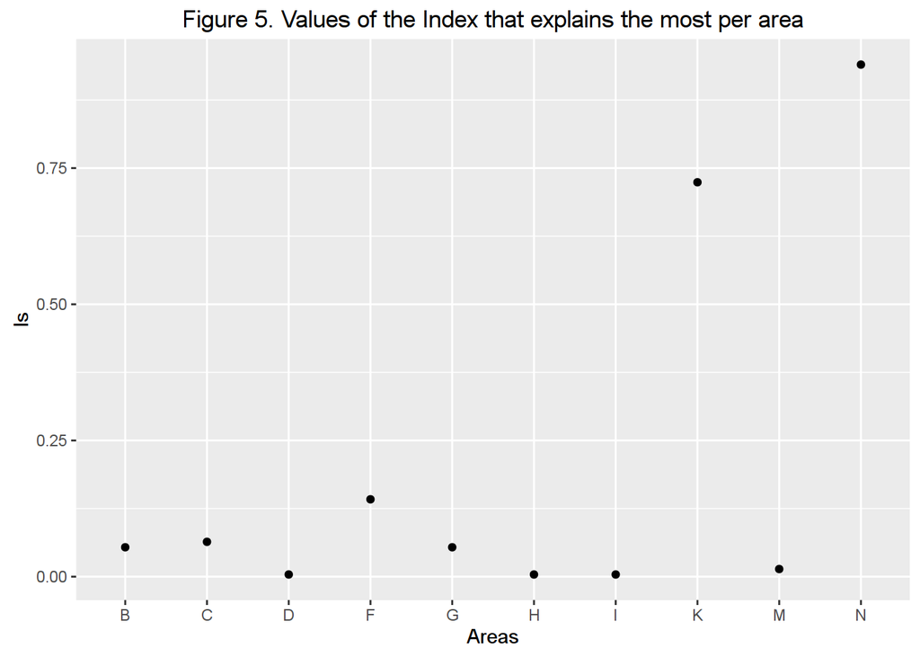

```r
best.Index.Multi <-   which.max(apply(correlations.Multi,2,sum))

qplot(initial.Values.Multi$area,initial.Values.Multi[,names(best.Index.Multi)], xlab = "Areas", ylab =names(best.Index.Multi), main = "Figure 5. Values of the Index that explains the most per area")
```

> **2.** A delete experiment: Prob jtip jtopol 0.5

```r
jack.Multi <-  Multi.Index.Calc(Multitaxon1,jtip = 0.5,jtopol = 0.5)
```

```
## [1] "Deleted  0  out of  20"
## [1] "Deleted  10  out of  20"
```

See that the `jtopol` and `jtip` present the deleted proportions, and the two data frames are different.

```r
all.equal(jack.Multi,initial.Values.Multi)
```

```
##  [1] "Component \"I\": Mean relative difference: 0.239779"
##  [2] "Component \"Ie\": Mean relative difference: 0.3470429"
##  [3] "Component \"Is\": Mean relative difference: 0.3236763"
##  [4] "Component \"Ise\": Mean relative difference: 1"
##  [5] "Component \"W\": Mean relative difference: 0.2862719"
##  [6] "Component \"We\": Mean relative difference: 0.2084375"
##  [7] "Component \"Ws\": Mean relative difference: 0.214"
##  [8] "Component \"Wse\": Mean relative difference: 1"
##  [9] "Component \"rich\": Mean relative difference: 0.3333333"
## [10] "Component \"endem\": Mean relative difference: 0.6774194"
## [11] "Component \"jtopol\": Mean relative difference: 1"
## [12] "Component \"jtip\": Mean relative difference: 1"
```

```r
vector <-   which.max(apply(correlations,2,sum))
```

**3.** Jack Ranking Multitaxon 100 times

This operation computes the index values and returns a data matrix. Diverse from the first method, it allows to perform this operation 100 times. The number of replicates can be easily modified, by changing the rank in for `(i in 1:100)`.

```r
jack.Ranking.100 <- list()

for (i in 1:100){
  print(paste("replicate #",i))
  jack.Ranking.100[[i]] <-  as.data.frame(Rank.Indices(Multi.Index.Calc(Multitaxon1,
  jtip = 0.5,jtopol = 0.5)))
}
```

```
## [1] "replicate # 1"
## [1] "Deleted  12  out of  20"
## [1] "Deleted  0  out of  20"
## [1] "replicate # 2"
## [1] "Deleted  16  out of  20"
## [1] "Deleted  0  out of  20"
## [1] "replicate # 3"
## [1] "Deleted  7  out of  20"
## [1] "Deleted  11  out of  20"
## [1] "replicate # 4"
## [1] "Deleted  0  out of  20"
## [1] "Deleted  0  out of  20"
## [1] "replicate # 5"
## [1] "Deleted  11  out of  20"
## [1] "Deleted  0  out of  20"
```

[output cut: 285 more lines]

We can get the ranking in the first run. It is only necessary to run this line:

```r
jack.Ranking.100[[1]][,vector]
```

```
##  [1] N K F C G B M D H I
## Levels: B C D F G H I K M N
```

**4.** Convert the initial values to a ranking

The initial ranking for Multitaxon is assigned as follows:

```r
initial.Ranking <-  as.data.frame(Rank.Indices(Multi.Index.Calc(Multitaxon1)))
```

```
## [1] "Deleted  0  out of  20"
## [1] "Deleted  0  out of  20"
```

```r
initial.Ranking[,vector]
```

```
##  [1] N K F C B G M D H I
## Levels: B C D F G H I K M N
```

**5.** Compare the whole ranking for the best index, 100 times.

```r
jack.Ranking.100.comparison <- NULL

for (i in 1:100){
  jack.Ranking.100.comparison[i] <- all.equal(initial.Ranking[,vector],
                                              jack.Ranking.100[[i]][,vector])
}
```

Compute the number of hits or the Jackknife replicate ability to recover the initial ranking:

```r
length(which(jack.Ranking.100.comparison==TRUE))
```

```
## [1] 35
```

As in the first example, get an estimation of the error.

```r
length(which(as.data.frame(jack.Ranking.100.comparison)!=TRUE))
```

```
## [1] 65
```

And with this instruction we can identify the type of error.

```r
jack.Mismatch <- jack.Ranking.100.comparison[jack.Ranking.100.comparison!=TRUE]

count.Jack.Mismatch <- gsub(" string mismatches","",jack.Mismatch)

count.Jack.Mismatch <- as.numeric(count.Jack.Mismatch)
```

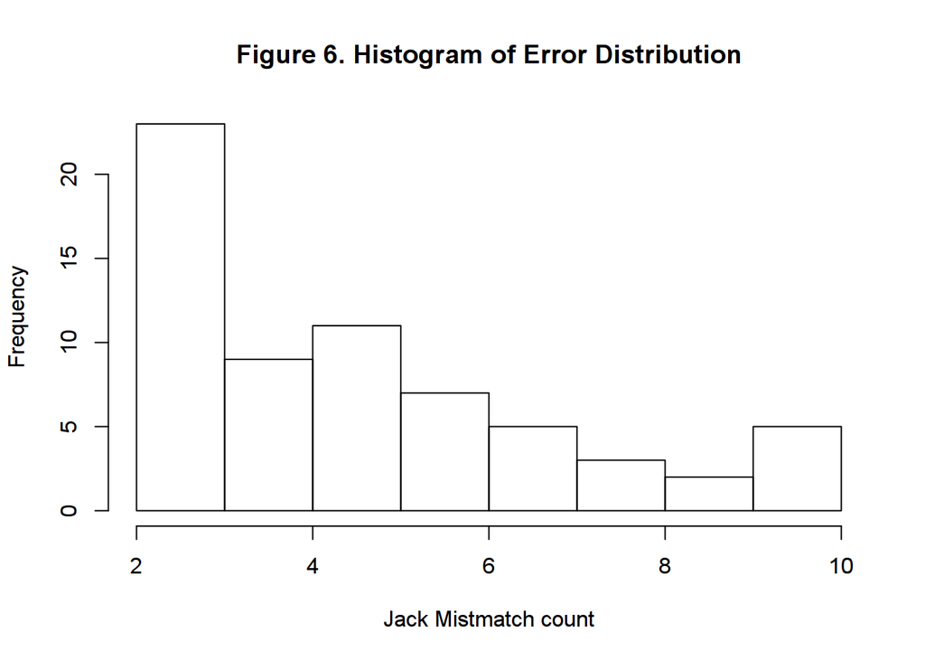

```r
hist(sort(count.Jack.Mismatch), main="Figure 6. Histogram of Error Distribution",  xlab= "Jack Mistmatch count")
```